# SAGE Gait Study

### Association of WHODAS variables and gait speed

The WHODAS variables are a series of questions that start with the following preamble: “Overall in the last 30 days, how much difficulty…”, followed by various parameters/tasks. As expected, generally, there is a statistically significant decrease in gait speed, as the respondents’ level of difficulty in accomplishing the task increases. The tables below gives a breakdown of the variables:

| **Characteristic** | **Ghana**, N = 4 835<sup>1</sup> | **South Africa**, N = 3 666<sup>1</sup> |
| --- | --- | --- |
| in sitting for long periods? |  |  |
| none | 2 224 (46%) | 2 264 (62%) |
| mild | 1 393 (29%) | 759 (21%) |
| moderate | 916 (19%) | 513 (14%) |
| severe | 289 (6·0%) | 118 (3·2%) |
| extreme | 8 (0·2%) | 7 (0·2%) |
| don't know | 5 (0·1%) | 5 (0·1%) |
| not applicable | 0 (0%) | 0 (0%) |
| in taking care of your household responsibilities? |  |  |
| none | 2 743 (57%) | 2 459 (67%) |
| mild | 1 132 (23%) | 545 (15%) |
| moderate | 714 (15%) | 460 (13%) |
| severe | 167 (3·5%) | 152 (4·1%) |
| extreme | 50 (1·0%) | 35 (1·0%) |
| don't know | 15 (0·3%) | 9 (0·2%) |
| not applicable | 14 (0·3%) | 6 (0·2%) |
| did you have in learning a new task? |  |  |
| none | 2 280 (47%) | 1 855 (51%) |
| mild | 1 298 (27%) | 709 (19%) |
| moderate | 980 (20%) | 805 (22%) |
| severe | 239 (4·9%) | 244 (6·7%) |
| extreme | 35 (0·7%) | 45 (1·2%) |
| don't know | 3 (<0·1%) | 8 (0·2%) |
| not applicable | 0 (0%) | 0 (0%) |
| in joining in community activities? |  |  |
| none | 2 733 (57%) | 2 563 (70%) |
| mild | 872 (18%) | 464 (13%) |
| moderate | 710 (15%) | 410 (11%) |
| severe | 308 (6·4%) | 144 (3·9%) |
| extreme | 159 (3·3%) | 52 (1·4%) |
| don't know | 11 (0·2%) | 15 (0·4%) |
| not applicable | 42 (0·9%) | 18 (0·5%) |
| concentrating on doing something for 10 minutes? |  |  |
| none | 3 076 (64%) | 2 220 (61%) |
| mild | 1 135 (23%) | 629 (17%) |
| moderate | 501 (10%) | 645 (18%) |
| severe | 91 (1·9%) | 142 (3·9%) |
| extreme | 16 (0·3%) | 21 (0·6%) |
| don't know | 12 (0·2%) | 9 (0·2%) |
| not applicable | 4 (<0·1%) | 0 (0%) |
| in walking a long distance such as a kilometer? |  |  |
| none | 2 158 (45%) | 1 893 (52%) |
| mild | 986 (20%) | 507 (14%) |
| moderate | 927 (19%) | 650 (18%) |
| severe | 485 (10%) | 461 (13%) |
| extreme | 256 (5·3%) | 145 (4·0%) |
| don't know | 5 (0·1%) | 10 (0·3%) |
| not applicable | 18 (0·4%) | 0 (0%) |
| in bathing/washing your whole body? |  |  |
| none | 4 057 (84%) | 3 279 (89%) |
| mild | 488 (10%) | 226 (6·2%) |
| moderate | 221 (4·6%) | 111 (3·0%) |
| severe | 47 (1·0%) | 32 (0·9%) |
| extreme | 8 (0·2%) | 11 (0·3%) |
| don't know | 9 (0·2%) | 7 (0·2%) |
| not applicable | 5 (0·1%) | 0 (0%) |
| in getting dressed? |  |  |
| none | 4 066 (84%) | 3 327 (91%) |
| mild | 458 (9·5%) | 187 (5·1%) |
| moderate | 260 (5·4%) | 117 (3·2%) |
| severe | 31 (0·6%) | 24 (0·7%) |
| extreme | 11 (0·2%) | 4 (0·1%) |
| don't know | 5 (0·1%) | 7 (0·2%) |
| not applicable | 4 (<0·1%) | 0 (0%) |
| with dealing with strangers? |  |  |
| none | 3 289 (68%) | 2 524 (69%) |
| mild | 717 (15%) | 474 (13%) |
| moderate | 572 (12%) | 458 (12%) |
| severe | 212 (4·4%) | 170 (4·6%) |
| extreme | 36 (0·7%) | 31 (0·8%) |
| don't know | 9 (0·2%) | 9 (0·2%) |
| not applicable | 0 (0%) | 0 (0%) |
| with making new friendships or maintaining current friendships? |  |  |
| none | 3 247 (67%) | 2 727 (74%) |
| mild | 804 (17%) | 460 (13%) |
| moderate | 537 (11%) | 332 (9·1%) |
| severe | 193 (4·0%) | 122 (3·3%) |
| extreme | 47 (1·0%) | 19 (0·5%) |
| don't know | 7 (0·1%) | 6 (0·2%) |
| not applicable | 0 (0%) | 0 (0%) |

<sup>1</sup> n (%)

| **Characteristic** | **N** | **Beta** | **95% CI**<sup>1</sup> | **p-value** |
| --- | --- | --- | --- | --- |
| in sitting for long periods? | 8 501 |  |  |  |
| none |  | — | — |  |
| mild |  | -0·12 | -0·14 to -0·10 | <0·001 |
| moderate |  | -0·15 | -0·18 to -0·13 | <0·001 |
| severe |  | -0·16 | -0·20 to -0·11 | <0·001 |
| extreme |  | -0·01 | -0·22 to 0·19 | 0·90 |
| don't know |  | -0·21 | -0·45 to 0·04 | 0·10 |
| in taking care of your household responsibilities? | 8 501 |  |  |  |
| none |  | — | — |  |
| mild |  | -0·10 | -0·12 to -0·08 | <0·001 |
| moderate |  | -0·13 | -0·15 to -0·10 | <0·001 |
| severe |  | -0·13 | -0·18 to -0·09 | <0·001 |
| extreme |  | -0·18 | -0·26 to -0·09 | <0·001 |
| don't know |  | -0·05 | -0·21 to 0·11 | 0·56 |
| not applicable |  | -0·20 | -0·37 to -0·02 | 0·029 |
| did you have in learning a new task? | 8 501 |  |  |  |
| none |  | — | — |  |
| mild |  | -0·12 | -0·14 to -0·10 | <0·001 |
| moderate |  | -0·16 | -0·18 to -0·14 | <0·001 |
| severe |  | -0·17 | -0·21 to -0·14 | <0·001 |
| extreme |  | -0·18 | -0·27 to -0·09 | <0·001 |
| don't know |  | 0·09 | -0·15 to 0·33 | 0·46 |
| in joining in community activities? | 8 501 |  |  |  |
| none |  | — | — |  |
| mild |  | -0·08 | -0·11 to -0·06 | <0·001 |
| moderate |  | -0·14 | -0·17 to -0·11 | <0·001 |
| severe |  | -0·15 | -0·19 to -0·11 | <0·001 |
| extreme |  | -0·14 | -0·20 to -0·09 | <0·001 |
| don't know |  | -0·25 | -0·41 to -0·10 | 0·001 |
| not applicable |  | -0·15 | -0·25 to -0·05 | 0·004 |
| concentrating on doing something for 10 minutes? | 8 501 |  |  |  |
| none |  | — | — |  |
| mild |  | -0·07 | -0·09 to -0·05 | <0·001 |
| moderate |  | -0·10 | -0·13 to -0·08 | <0·001 |
| severe |  | -0·09 | -0·15 to -0·04 | <0·001 |
| extreme |  | -0·25 | -0·38 to -0·12 | <0·001 |
| don't know |  | -0·15 | -0·32 to 0·03 | 0·095 |
| not applicable |  | -0·17 | -0·56 to 0·23 | 0·41 |
| in walking a long distance such as a kilometer? | 8 501 |  |  |  |
| none |  | — | — |  |
| mild |  | -0·08 | -0·10 to -0·06 | <0·001 |
| moderate |  | -0·16 | -0·18 to -0·13 | <0·001 |
| severe |  | -0·20 | -0·23 to -0·17 | <0·001 |
| extreme |  | -0·19 | -0·23 to -0·15 | <0·001 |
| don't know |  | -0·25 | -0·46 to -0·05 | 0·014 |
| not applicable |  | -0·34 | -0·53 to -0·16 | <0·001 |
| in bathing/washing your whole body? | 8 501 |  |  |  |
| none |  | — | — |  |
| mild |  | -0·01 | -0·04 to 0·02 | 0·67 |
| moderate |  | -0·02 | -0·06 to 0·03 | 0·41 |
| severe |  | -0·15 | -0·24 to -0·06 | 0·001 |
| extreme |  | -0·17 | -0·35 to 0·02 | 0·074 |
| don't know |  | 0·03 | -0·16 to 0·23 | 0·73 |
| not applicable |  | -0·19 | -0·55 to 0·16 | 0·29 |
| in getting dressed? | 8 501 |  |  |  |
| none |  | — | — |  |
| mild |  | -0·01 | -0·04 to 0·02 | 0·64 |
| moderate |  | -0·03 | -0·07 to 0·01 | 0·21 |
| severe |  | -0·20 | -0·31 to -0·09 | <0·001 |
| extreme |  | 0·26 | 0·06 to 0·47 | 0·012 |
| don't know |  | 0·06 | -0·17 to 0·29 | 0·61 |
| not applicable |  | -0·22 | -0·62 to 0·18 | 0·28 |
| with dealing with strangers? | 8 501 |  |  |  |
| none |  | — | — |  |
| mild |  | -0·05 | -0·08 to -0·03 | <0·001 |
| moderate |  | -0·06 | -0·09 to -0·03 | <0·001 |
| severe |  | -0·13 | -0·17 to -0·09 | <0·001 |
| extreme |  | -0·10 | -0·20 to 0·00 | 0·047 |
| don't know |  | 0·19 | 0·00 to 0·37 | 0·050 |
| with making new friendships or maintaining current friendships? | 8 501 |  |  |  |
| none |  | — | — |  |
| mild |  | -0·04 | -0·07 to -0·02 | <0·001 |
| moderate |  | -0·07 | -0·10 to -0·04 | <0·001 |
| severe |  | -0·11 | -0·16 to -0·06 | <0·001 |
| extreme |  | -0·08 | -0·18 to 0·02 | 0·12 |
| don't know |  | -0·05 | -0·27 to 0·17 | 0·65 |

<sup>1</sup> CI = Confidence Interval

### Trend of Gait Speed With Age

It can be seen clearly in the graphs below that there is a decline in gait speed with increasing age:

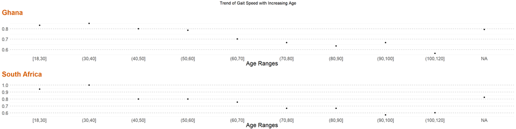

### Zooming In To 60+

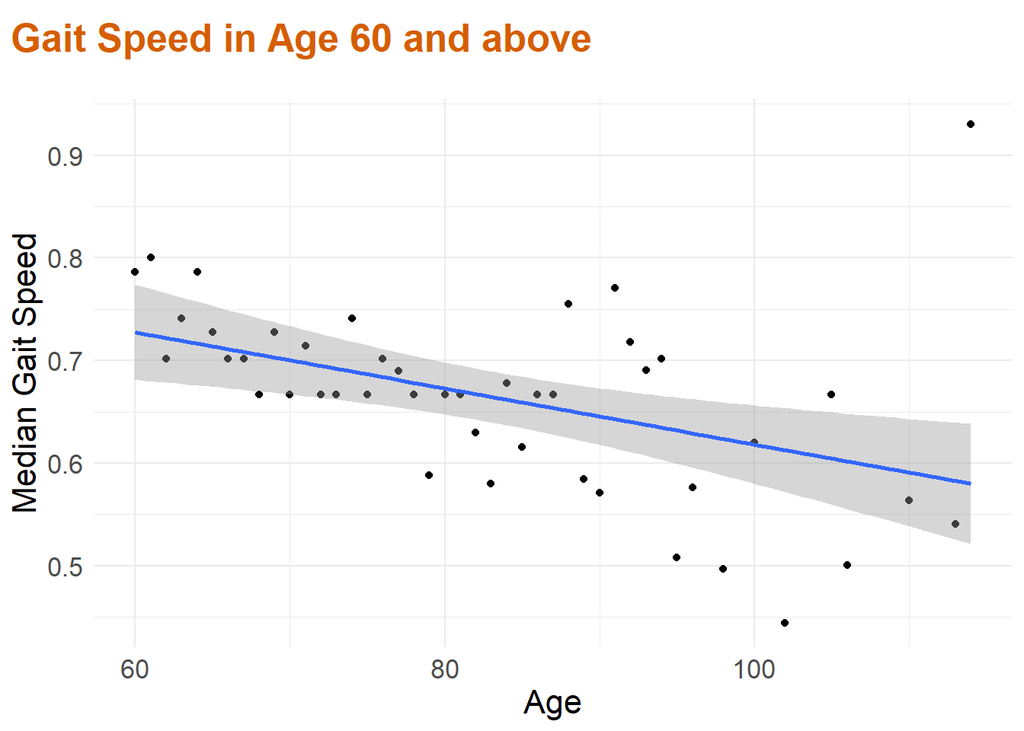

### Gender vs Normal and Rapid Gait Speed

The results below suggest that the male gender is associated with slightly higher gait speed:

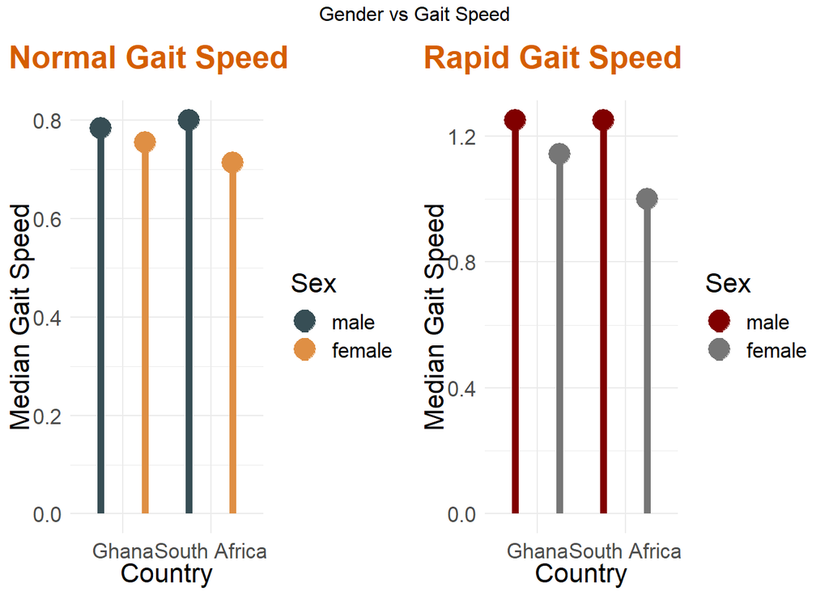

### Respondents’subjective assessment of pain, health and energy levels

| **Characteristic** | **Ghana**, N = 4 835<sup>1</sup> | **South Africa**, N = 3 666<sup>1</sup> |
| --- | --- | --- |
| Health Rating |  |  |
| very good | 333 (6·9%) | 230 (6·3%) |
| good | 1 920 (40%) | 1 341 (37%) |
| moderate | 1 903 (39%) | 1 593 (43%) |
| bad | 595 (12%) | 447 (12%) |
| very bad | 82 (1·7%) | 51 (1·4%) |
| don't know | 2 (<0·1%) | 4 (0·1%) |
| not applicable | 0 (0%) | 0 (0%) |
| Difficulty with activities |  |  |
| none | 1 189 (25%) | 1 597 (44%) |
| mild | 1 175 (24%) | 604 (16%) |
| moderate | 1 854 (38%) | 1 172 (32%) |
| severe | 537 (11%) | 247 (6·7%) |
| extreme | 68 (1·4%) | 20 (0·5%) |
| don't know | 12 (0·2%) | 26 (0·7%) |
| not applicable | 0 (0%) | 0 (0%) |
| Difficulty due to pain |  |  |
| none | 391 (11%) | 274 (12%) |
| mild | 1 650 (45%) | 880 (39%) |
| moderate | 1 147 (31%) | 778 (34%) |
| severe | 414 (11%) | 251 (11%) |
| extreme | 10 (0·3%) | 6 (0·3%) |
| don't know | 60 (1·6%) | 85 (3·7%) |
| not applicable | 1 (<0·1%) | 0 (0%) |
| Unknown | 1 162 | 1 392 |
| Difficulty due to lack of energy |  |  |
| none | 2 265 (47%) | 2 117 (58%) |
| mild | 1 255 (26%) | 721 (20%) |
| moderate | 1 039 (21%) | 578 (16%) |
| severe | 267 (5·5%) | 229 (6·2%) |
| extreme | 8 (0·2%) | 9 (0·2%) |
| don't know | 1 (<0·1%) | 12 (0·3%) |
| not applicable | 0 (0%) | 0 (0%) |

<sup>1</sup> n (%)

### Association of Pain, Health Rating and Energy Levels with gait speed

There is a statistically significant decrease in gait speed with a poor ranking of respondents’pain levels, health rating and energy levels.

| **Characteristic** | **N** | **Beta** | **95% CI**<sup>1</sup> | **p-value** |
| --- | --- | --- | --- | --- |
| Health Rating | 8 501 |  |  |  |
| very good |  | — | — |  |
| good |  | -0·11 | -0·15 to -0·07 | <0·001 |
| moderate |  | -0·23 | -0·26 to -0·19 | <0·001 |
| bad |  | -0·23 | -0·27 to -0·18 | <0·001 |
| very bad |  | -0·22 | -0·30 to -0·15 | <0·001 |
| don't know |  | -0·21 | -0·53 to 0·12 | 0·21 |
| Difficulty due to pain | 5 947 |  |  |  |
| none |  | — | — |  |
| mild |  | -0·04 | -0·08 to -0·01 | 0·014 |
| moderate |  | -0·05 | -0·09 to -0·02 | 0·002 |
| severe |  | -0·08 | -0·12 to -0·04 | <0·001 |
| extreme |  | -0·11 | -0·30 to 0·09 | 0·29 |
| don't know |  | -0·05 | -0·12 to 0·03 | 0·21 |
| not applicable |  | -0·40 | -1·2 to 0·38 | 0·31 |
| Difficulty due to lack of energy | 8 501 |  |  |  |
| none |  | — | — |  |
| mild |  | -0·09 | -0·11 to -0·07 | <0·001 |
| moderate |  | -0·08 | -0·10 to -0·06 | <0·001 |
| severe |  | -0·12 | -0·15 to -0·08 | <0·001 |
| extreme |  | -0·18 | -0·37 to 0·01 | 0·068 |
| don't know |  | -0·06 | -0·28 to 0·16 | 0·56 |
| Difficulty with activities | 8 501 |  |  |  |
| none |  | — | — |  |
| mild |  | -0·10 | -0·13 to -0·08 | <0·001 |
| moderate |  | -0·16 | -0·18 to -0·14 | <0·001 |
| severe |  | -0·21 | -0·24 to -0·17 | <0·001 |
| extreme |  | -0·20 | -0·28 to -0·11 | <0·001 |
| don't know |  | -0·09 | -0·22 to 0·04 | 0·17 |

<sup>1</sup> CI = Confidence Interval

#### Related Graphs

The figures below are graphical representations of the above parameters.

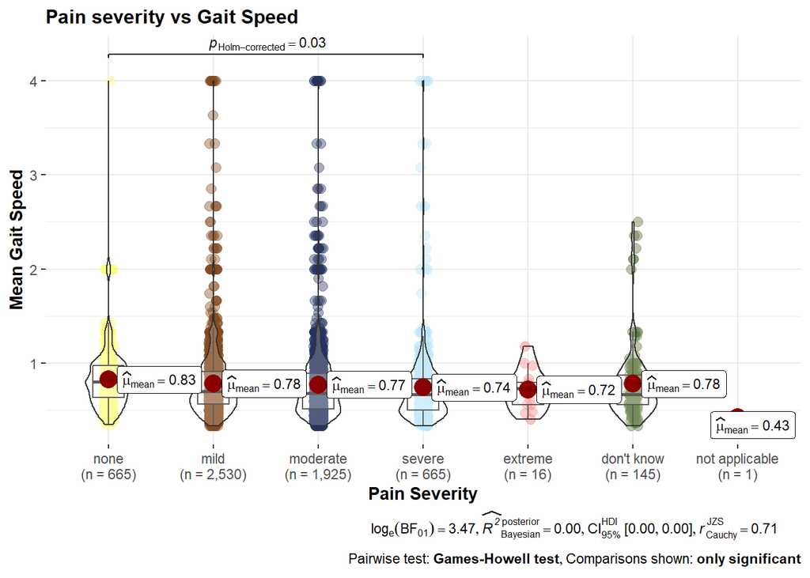

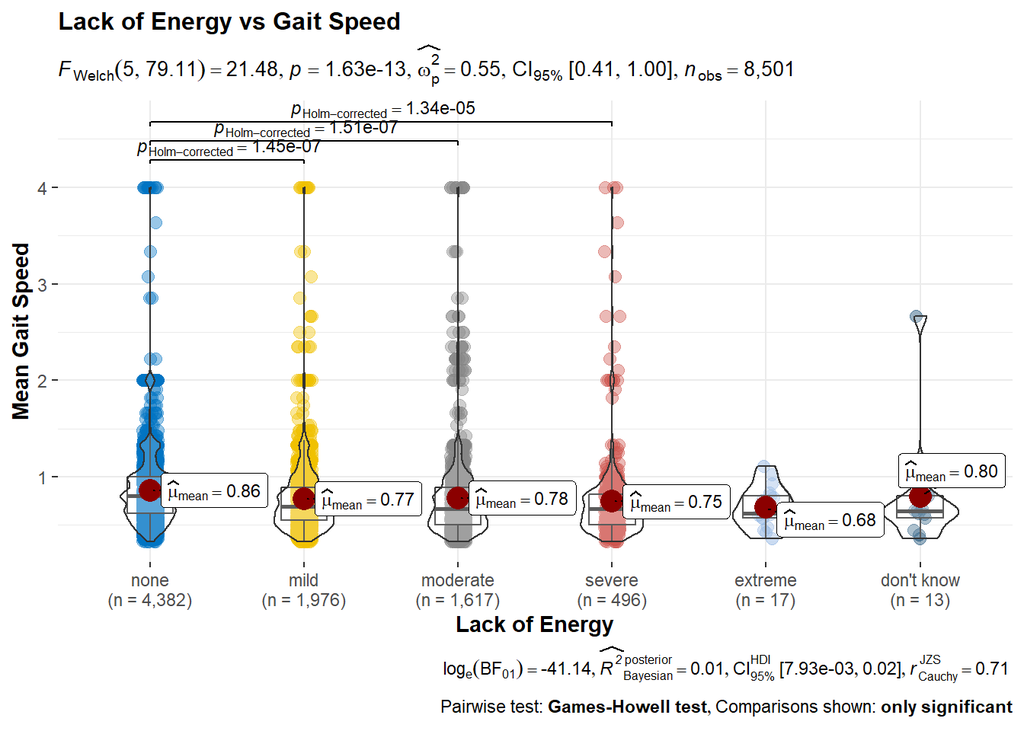

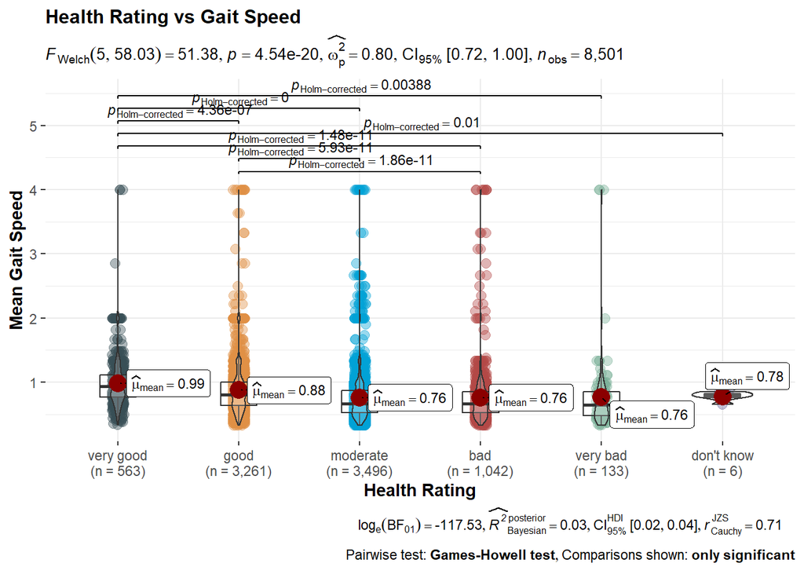

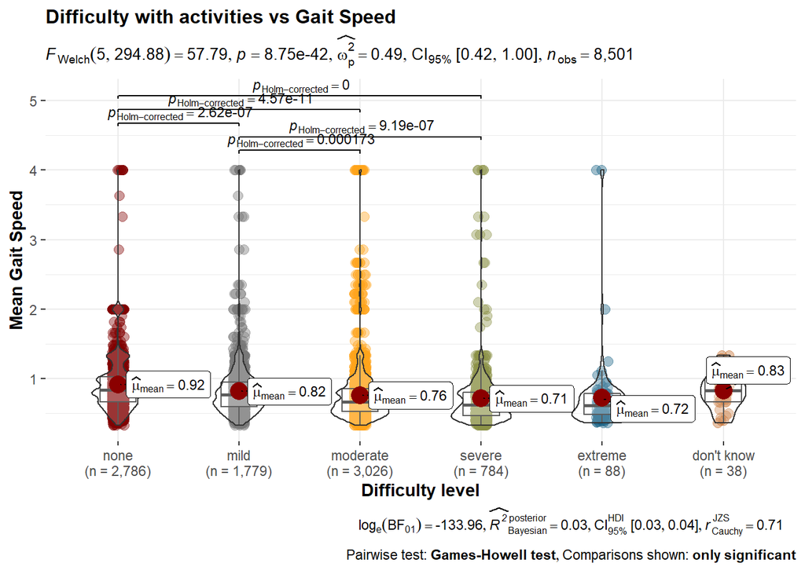

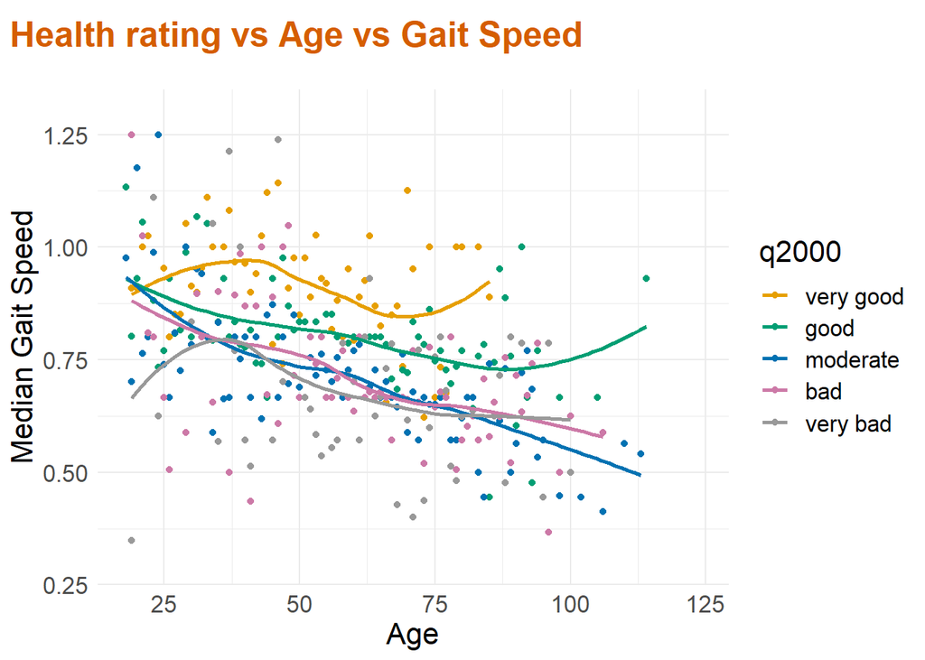

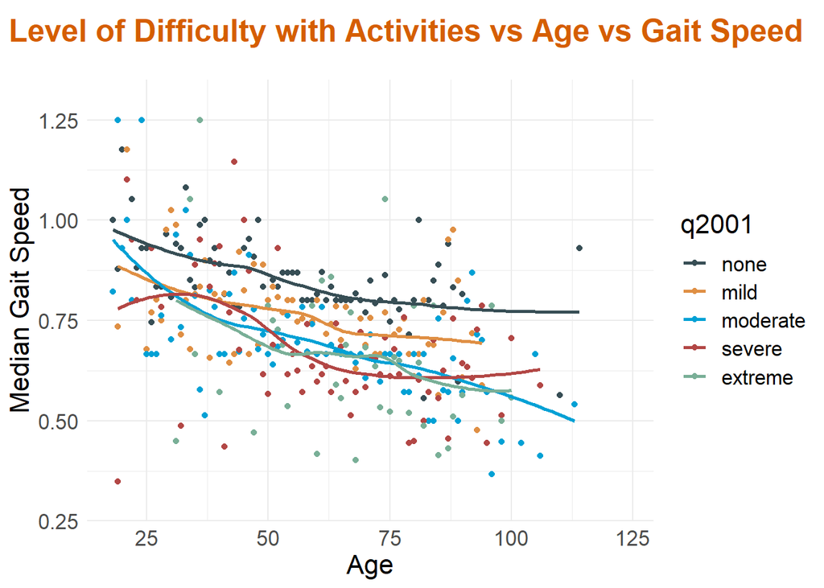